# Learning - R

Jino Surendra

2025-04-03

This is an activity created by Dr. Antonio Paez, from his Session 2 Notes.

# My Goal to Become an Internal Doctor

*The following is an AI-created (ChatGPT by OpenAI) and human-refined paragraph.*

I’m finishing my first year of university as a **Life Sciences student**, and I’ve become really motivated to pursue a career in **internal medicine**. This year, I’ve taken courses like:

- BIO 1A03
- CHEM 1A03 and CHEM 1AA3
- PHYSICS 1A03
- MATH 1LS3

These courses helped me understand *how the body works*, and it made me realize how much I *enjoy learning about health and disease*. What I like most about internal medicine is how doctors work with *adult patients* to figure out what’s going on when something’s wrong and help manage long-term conditions. I think it’s amazing how they **use both science and problem-solving** to help people feel better and stay healthy. I also like that internal medicine doctors get to build strong relationships with their patients over time. I want to be someone who **listens, understands, and makes a real difference in people’s lives**. As I continue through university, I plan to get involved in *volunteering, research, and maybe even shadow doctors* so I can learn more about the field and prepare for medical school. Becoming a doctor is a **big goal**, but it’s one that feels right for me, and I’m excited to keep working toward it.

# Favorites

## Favorite Music

Below are a list of my **favorite songs** at the moment:

1. Joro - *Wizkid*
2. Don’t Go Breaking My Heart - *Elton John, Kiki Dee*
3. GOOD CREDIT - *Playboi Carti feat. Kendrick Lamar*
4. Magic Don Juan (Princess Diana) - *Metro Boomin, Future*
5. Fight For Your Right - *Beastie Boys*

As you can see, I listen to pretty much any music that has been released.

## Favorite Equation

My favorite equation, I would say in my life, is the plain and simple Einstein’s mass-energy equivalence formula: $E = mc^2$.

When I was young, I always looked at this equation as a super complex equation that only the best of scientists knew how to use. But, when I got to Grade 11, I learned how simple it is, how easy it is to apply and use when needed.

## Favorite Artists

Below is a table of my favorite artists along with one of their most notable achievements:

| Artist Name | Achievement |
| --- | --- |
| Metro Boomin | Best Rap Song (*2024*) |
| 21 Savage | Album of The Year (*2024*) |
| Post Malone | Best Country Album (*2025*) |
| Young Thug | Best Rap Performance (*2023*) |
| WizKid | Songwriter for First Song to Reach 1,000,000,000 Streams on Spotify |

# A Chunk of Code

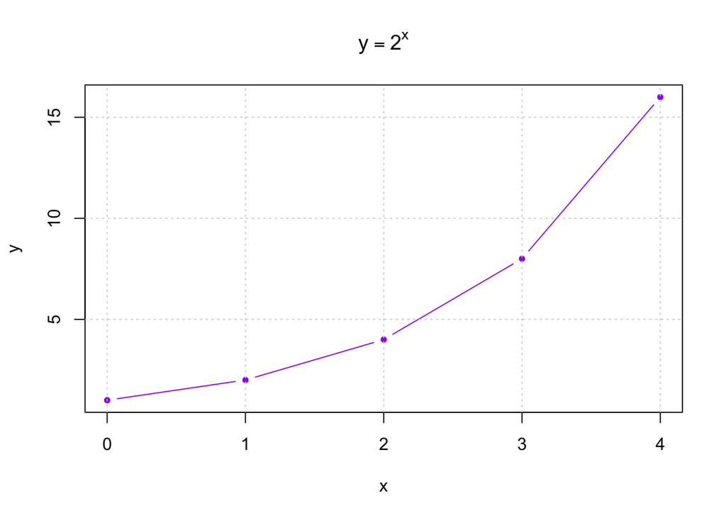

```r
# Below is a chunk of code that plots out a graph of y = 2^x.

# Define x values (5 points).
# 0 is counted as the first value in R.
x <- c(0, 1, 2, 3, 4)

# Caclulate y = 2^x.
y <- 2^x

# Plot the points
# Type "b" refers to the type of graph, this connects the points and shows dots.
# Color can also be chosen, I chose purple as it is my favorite color.
# Expression refers to the title which currently shows the equation of the graph.
plot(x, y, type = "b", col = "purple", pch = 20,
     main = expression(y == 2^x),
     xlab = "x", ylab = "y")

# Adds grid lines to the graph for clarity
grid()
```